# Análise de dados ambientais com R (ADAR)

Jonatan Tatsch, UFSM  
Santa Maria, 14, março de 2018

[figure not shown]

### Introdução

## Análise de dados meteorológicos

> Processo pelo qual adquire-se conhecimento, compreensão e percepção dos fenômenos meteorológicos a partir de observações (dados) qualitativas e quantitativas.

[figure not shown]

### Ciência de dados

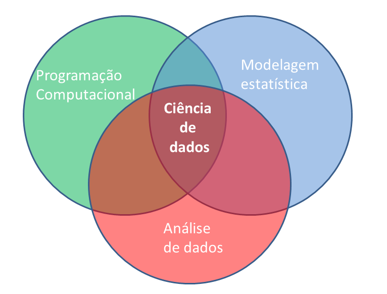

### Etapas para abordagem de um problema

1. **Questão científica/problema**
2. **Obtenção de dados:** coleta/medida do(as) estado/condições da atmosfera
   - Instrumentos e sensores
3. **Processamento de dados:** *download* —> limpeza —> formatação —>  
   transformação —> controle de qualidade
   - ferramenta/software
     - conhecimento em programação
4. **Análise de dados**
   - ferramenta/software
     - conhecimento em programação
5. **Solução para o problema**
   - Proposta de um modelo
     - estatístico, empírico, ou fisicamente baseado
   - conhecimento em programação
6. **Apresentação/divulgação/publicação**

### Programação computacional

[figure not shown]

[figure not shown]

[figure not shown]

- [R](https://www.r-project.org/) é o termo usado para se referir a linguagem de programação e ao software que interpreta os scripts escritos usando esta linguagem.
- Comunidade fantástica
  - [Contribuidores](https://www.r-project.org/contributors.html) (R-core Team)
  - milhares de pessoas usam o R diariamente e ajudam outras pessoas
- **Software Livre** (GPL), [Código aberto](https://github.com/wch/r-source) e multiplataforma
- Ambiente para Análise de dados interativa

### Por que o R?

- [R](https://www.r-project.org/) não é uma GUI (Interface gráfica do usuário) e isso é bom
  - há uma natural resistência e dificuldade ao uso de códigos e scripts
  - scripts favorecem a **automatização** e **reprodutibilidade**
  - força você a ter um conhecimneto mais aprofundado do que está fazendo
- Reprodutibilidade
  - qualquer pessoa (inclusive você mesmo no futuro) pode obter os mesmos resultados do mesmo conjunto de dados
  - R é integrado com [outras ferramentas](https://cran.r-project.org/web/views/ReproducibleResearch.html) de que permitem atualizar seus resultados, figuras e análises automaticamente
  - [Relatório dinâmicos](https://rmarkdown.rstudio.com/articles_intro.html) e [interativos](http://shiny.rstudio.com/)

### Por que o R?

- Acesso ao estado da arte da ciência de dados (*Big Data*, *Data Mining*, *Machine Leraning*)
- Interface com Fortran, C, C++, Python
- [Visualização de dados](https://cran.r-project.org/web/views/Graphics.html)
  - R produz [gráficos de alta qualidade](https://timogrossenbacher.ch/2016/12/beautiful-thematic-maps-with-ggplot2-only/)
- R trabalha com dados de todas formas e tamanhos
- Extensões para [Manipulação de dados](http://blog.rstudio.org/2014/07/22/introducing-tidyr/)

### Por que um meteorologista usaria o R?

A meteorologia é 4D:

```r
meteorologia <- function(x, y, z, t){
  ...muita coisa para caber em um slide...
}
```

Logo, requer ferramentas específicas para:

- manipulação de dados espacias
- análise de séries temporais
- importação e ferramentas de [SIG](https://pt.wikipedia.org/wiki/Sistema_de_informa%C3%A7%C3%A3o_geogr%C3%A1fica)
- leitura de dados em formatos específicos ([netcdf](https://en.wikipedia.org/wiki/NetCDF), [binários](https://en.wikipedia.org/wiki/Binary_file), [grib2](https://en.wikipedia.org/wiki/GRIB), …)

### R não é perfeito!

- Muitos códigos em R são escritos para resolver um problema;
  - foco nos resultados e não no processo
  - usuários não são programadores
  - códigos deselegantes, lentos e difíceis de entender
- Como o nosso idioma, há muitas exceções para serem lembradas
- R não é muito rápido e códigos mal escritos serão lentos
- São apenas ~20 anos de evolução
- Há muito o que melhorar

### RStudio

[RStudio](https://www.rstudio.com/) é um **ambiente de desenvolvimento integrado** livre e de código aberto.

[figure not shown]

- Multiplataforma (Windos, Linux e Mac)
- ênfase da sintaxe do R, auto-preenchimento de código, identação inteligente
- execução do R diretamente do editor
- manejo de diretórios e projetos
- histórico de gráficos, zoom, atalhos para exportar imagens
- Integrado com [knitr](https://en.wikipedia.org/wiki/Knitr)
- Integrado com [GitHub](https://github.com/) para controle de versões

Material do curso disponível no [GitHub](https://github.com/jdtatsch/adar-ufsm)

### Para saber mais sobre o R

[**Documentação oficial**](http://cran.r-project.org/manuals.html)  
[**Livros relacionados ao R**](http://www.r-project.org/doc/bib/R-books.html)

- [Livros gratuitos](https://github.com/vhf/free-programming-books/blob/master/free-programming-books.md#r)

**Fóruns:**

- lista Brasileira de discussão do programa R: [**R-br**](https://listas.inf.ufpr.br/cgi-bin/mailman/listinfo/r-br)
- [stackoverflow](http://stackoverflow.com/questions/tagged/r)  
  Próximo: [Instalando o R e Rstudio](https://rawgit.com/jdtatsch/adar-ufsm/master/1_Rinstall.html)

### Bibliografia

**Básica**

R FOR DATA SCIENCE. Garret Grolemund, Hadley Wickham. Chambers (O’Reilly). 2016.

EFFICIENT R PROGRAMMING. Colin Gillespie and Robin Lovelace. (O’Reilly). 2016.

R IN A NUTSHELL, A Desktop Quick Reference. 2nd Edition. (O’Reilly). 2012.

DISLAYING TIME SERIES, SPATIAL AND SPACE-TIME DATA WITH R. Oscar Lamigueiro. (CRS PRESS). 2014.

**Complementar**

HANDS-ON PROGRAMMING WITH R. 1998.Garret Grolemund (O'Reilly).

TIME SERIES ANALYSIS AN WITH APPLICATIONS IN R. 2008 Cryer J.D. & Chan K.S. (Springer)

MODERN OPTIMIZATION WITH R. Paulo Cortez (Springer). 2014

ADVANCED R. Hadley Wickham. (O’Reilly). 2015.

SIMULATION OF ECOLOGICAL AND ENVIRONMENTAL MODELS. Miguel Acevedo. 2012. CRC Press.